# R Notebook

Orlando Sabogal

21/4/2020

```r
library(tidyverse)
library(magrittr)
library(sf)
library(tmap)

library(ggalluvial)
```

```r
Data <- read_delim("EncuestaCOVID.csv", delim = ",")
Locations <- st_read("por-favor-ubique-su-hogar-o-la-interseccion-mas-cercana.shp")

GrupoIngresos <- data.frame(Estrato = c(1,2,3,4,5,6),
                            Ingresos = c(1,1,2,2,3,3))
```

```r
#268 320

VariablesToUse <- c(
  1, #Respondent
  14, # Estrato
  19, #Género
  48, #Adultos mayores en el hogar

  109, #Modo Prepandemia
  145, #Tiempo en Actividad Principal
  175, #Modo Actual Actividad Princiapl

  309, #Cómo realiza compras actualmente (en lock-down)
  654, #Está haciendo sus actividades de salud

  718, #Tiempo respecto a antes
  719, #Afectación Económica
  720, #Medidas Tomadas
  721, #Forzado Aprender Nuevas Tecnología

  734 #Duración segundos
)
```

```r
names(Data)[VariablesToUse] <- c(
    "respondent",
    "Estrato", "Genero",
    "AdultosMayores",
    "ModoPrevio",
    "TiempoActPrinc",
    "ModoActPrinc",
    "Compras", "ActividadesSalud",
    "Tiempo", "AfectEconomica", "Medidas", "AprenderNT",
    "dur_second"
    )
```

```r
Data %<>% select(VariablesToUse)
```

```r
length(VariablesToUse)
```

```r
names(Data)
dim(Data)
```

```r
Data %<>% filter(dur_second > 60*5 & dur_second < 3*60*60)
dim(Data)
```

```r
summary(Data)
```

```r
Data %<>% left_join(GrupoIngresos)
```

# Basic Variables

## Actividades Salud

```r
#Muchos NA
summary(as.factor(Data$ActividadesSalud))

Data$ActividadesSalud <- as.factor(Data$ActividadesSalud)

Data_Salud <- Data %>% filter(Estrato >0) %>% select(respondent, Ingresos, ActividadesSalud)
Data_Salud <- Data_Salud[complete.cases(Data_Salud),]

Data_Salud <- Data_Salud %>% group_by(Ingresos, ActividadesSalud) %>%
  summarise(Total = n()) %>% ungroup()


Data_Salud %<>% pivot_wider(id_cols = Ingresos, names_from = ActividadesSalud, values_from = Total)
names(Data_Salud) <- c("Ingreso", "No", "Si")

Data_Salud2 <- Data_Salud %>% mutate(Total = No + Si) %>%
  mutate(No = round(No/Total, 4)*100,
         Si = round(Si/Total, 4)*100) %>%
  select(-Total)
```

```r
Data_Salud2
```

| Ingreso | No | Si |
| --- | --- | --- |
| 1 | 71.72 | 28.28 |
| 2 | 72.73 | 27.27 |
| 3 | 70.26 | 29.74 |

## Compras

```r
Data$Compras <- as.factor(Data$Compras)

Data_Compras <- Data %>% filter(Estrato >0) %>% select(respondent, Ingresos, Compras)
Data_Compras <- Data_Compras[complete.cases(Data_Compras),]

ComprasSummary <- Data_Compras %>% group_by(Ingresos, Compras) %>%
  summarise(Total = n()) %>% ungroup()


ComprasSummary %<>% pivot_wider(id_cols = Ingresos, names_from = Compras, values_from = Total)
names(ComprasSummary) <- c("Ingreso", "Domicilio", "Salir")

ComprasSummary2 <- ComprasSummary %>% mutate(Total = Domicilio + Salir) %>%
  mutate(Domicilio = round(Domicilio/Total, 4)*100,
         Salir = round(Salir/Total, 4)*100) %>%
  select(-Total)
```

```r
ComprasSummary2
```

| Ingreso | Domicilio | Salir |
| --- | --- | --- |
| 1 | 12.3 | 87.7 |
| 2 | 33.4 | 66.6 |
| 3 | 43.6 | 56.4 |

```r
NA
```

```r
Test <- ComprasSummary2 %>% pivot_longer(names_to = "FormaCompra", cols = -Ingreso)

ggplot(Test) + geom_bar(aes(fill = FormaCompra, x = Ingreso, y = value),
                        position="stack", stat="identity") +
  xlab("") + ylab("Porcentaje") +
  scale_x_continuous(breaks = c(1,2,3),
                     labels = c("Estratos 1 y 2", "Estratos 3 y 4", "Estratos 5 y 6")) +
  scale_y_continuous(breaks = seq(0,100,10),
                     labels = paste(seq(0,100,10),"%")) +
  geom_text(aes(fill = FormaCompra, x = Ingreso, y = value, label = paste(value, "%", sep = " ")),
            position = position_stack(vjust = .5), size = 3) +
  scale_fill_discrete(name = "Compras") +
  # scale_color_manual(name = "Densidad Población Migrante",
  #                    values = c("#66c2a5", "#fc8d62", "#8da0cb", "#e78ac3"),
  #                    labels = c("Baja", "Moderada", "Alta", "Muy Alta")) +
  theme_minimal()
```

```
Ignoring unknown aesthetics: fill
```

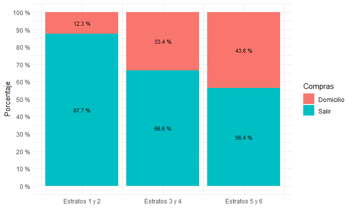

```r
ggsave("PlotCompras.jpeg")
```

## Tiempo

Pregunta: ¿Qué tan satisfecho está con la distribución de su tiempo respecto a antes de la pandemia?

```r
Data_Tiempo <- Data %>% filter(Estrato >0) %>% select(respondent, Ingresos, Tiempo)
Data_Tiempo <- Data_Tiempo[complete.cases(Data_Tiempo),]

TiempoSummary <- Data_Tiempo %>% group_by(Ingresos, Tiempo) %>%
  summarise(Total = n()) %>% ungroup()


TiempoSummary %<>% pivot_wider(id_cols = Ingresos, names_from = Tiempo, values_from = Total)
names(TiempoSummary) <- c("Ingreso", "TotalDes", "Des", "Medio", "Deacuerdo", "TotalmDeacuerdo")

TiempoSummary2 <- TiempoSummary
TiempoSummary2$Total <- apply(TiempoSummary2[,-1],1,sum)

TiempoSummary2[,c(2:6)] <- TiempoSummary2[,c(2:6)]/TiempoSummary2$Total
TiempoSummary2[,c(2:6)] <- round(TiempoSummary2[,c(2:6)]*100,2)

TiempoSummary2 %<>% select(-Total)
```

```r
TiempoSummary2
```

| Ingreso | TotalDes | Des | Medio | Deacuerdo | TotalmDeacuerdo |
| --- | --- | --- | --- | --- | --- |
| 1 | 8.28 | 31.36 | 11.24 | 33.73 | 15.38 |
| 2 | 10.16 | 33.82 | 4.68 | 35.03 | 16.31 |
| 3 | 9.59 | 33.15 | 9.32 | 37.81 | 10.14 |

```r
NA
```

```r
Test <- TiempoSummary2 %>% pivot_longer(names_to = "Category", cols = -Ingreso)

ggplot(Test) + geom_bar(aes(fill = Category, x = Ingreso, y = value),
                        position="stack", stat="identity") +
  xlab("") + ylab("Porcentaje") +
  scale_x_continuous(breaks = c(1,2,3),
                     labels = c("Estratos 1 y 2", "Estratos 3 y 4", "Estratos 5 y 6")) +
  scale_y_continuous(breaks = seq(0,100,10),
                     labels = paste(seq(0,100,10),"%")) +
  scale_fill_manual(name = "Clasificación",
                    values = c("#66c2a5", "#fc8d62",
                                "#8da0cb",
                               "#e78ac3", "#a6d854"),
                      labels = c("Tot. de acuerdo", "De acuedo",
                                 "Neutro",
                                 "Desacuertdo", "Tot. desacuerdo")) +
  geom_text(aes(fill = Category, x = Ingreso, y = value, label = paste(value, "%", sep = " ")),
            position = position_stack(vjust = .5), size = 3) +
  labs(caption = "¿Qué tan satisfecho está con la distribución de su tiempo respecto a antes de la pandemia?") +
  theme_minimal()
```

```
Ignoring unknown aesthetics: fill
```

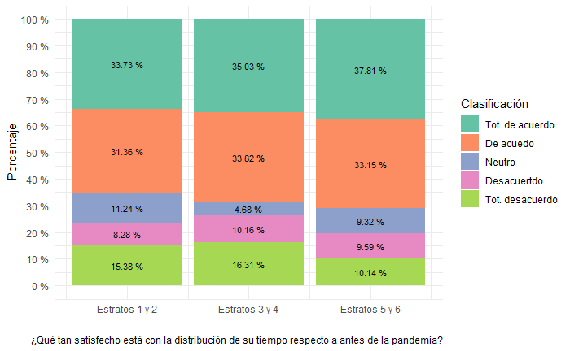

```r
ggsave("PlotTiempo.jpeg")
```

## Actividades Económicas

Pregunta: ¿Cuánto ha afectado su situación económica esta cuarentena?

```r
Data_Economico <- Data %>% filter(Estrato >0) %>% select(respondent, Ingresos, AfectEconomica)
Data_Economico <- Data_Economico[complete.cases(Data_Economico),]

EconomicoSummary <- Data_Economico %>% group_by(Ingresos, AfectEconomica) %>%
  summarise(Total = n()) %>% ungroup()


EconomicoSummary %<>% pivot_wider(id_cols = Ingresos, names_from = AfectEconomica, values_from = Total)
names(EconomicoSummary) <- c("Ingreso", "TotalDes", "Des", "Medio", "Deacuerdo", "TotalmDeacuerdo")

EconomicoSummary2 <- EconomicoSummary
EconomicoSummary2$Total <- apply(EconomicoSummary2[,-1],1,sum)

EconomicoSummary2[,c(2:6)] <- EconomicoSummary2[,c(2:6)]/EconomicoSummary2$Total
EconomicoSummary2[,c(2:6)] <- round(EconomicoSummary2[,c(2:6)]*100,2)

EconomicoSummary2 %<>% select(-Total)
```

```r
EconomicoSummary2
```

| Ingreso | TotalDes | Des | Medio | Deacuerdo | TotalmDeacuerdo |
| --- | --- | --- | --- | --- | --- |
| 1 | 9.64 | 13.20 | 9.14 | 35.53 | 32.49 |
| 2 | 22.48 | 22.09 | 5.49 | 29.37 | 20.56 |
| 3 | 26.01 | 21.45 | 6.70 | 25.20 | 20.64 |

```r
NA
```

```r
Test <- EconomicoSummary2 %>% pivot_longer(names_to = "Category", cols = -Ingreso)

ggplot(Test) + geom_bar(aes(fill = Category, x = Ingreso, y = value),
                        position="stack", stat="identity") +
  xlab("") + ylab("Porcentaje") +
  scale_x_continuous(breaks = c(1,2,3),
                     labels = c("Estratos 1 y 2", "Estratos 3 y 4", "Estratos 5 y 6")) +
  scale_y_continuous(breaks = seq(0,100,10),
                     labels = paste(seq(0,100,10),"%")) +
  scale_fill_manual(name = "Clasificación",
                    values = c("#66c2a5", "#fc8d62",
                                "#8da0cb",
                               "#e78ac3", "#a6d854"),
                      labels = c("Tot. de acuerdo", "De acuedo",
                                 "Neutro",
                                 "Desacuertdo", "Tot. desacuerdo")) +
  geom_text(aes(fill = Category, x = Ingreso, y = value, label = paste(value, "%", sep = " ")),
            position = position_stack(vjust = .5), size = 3) +
  labs(caption = "¿Cuánto ha afectado su situación económica esta cuarentena?") +
  theme_minimal()
```

```
Ignoring unknown aesthetics: fill
```

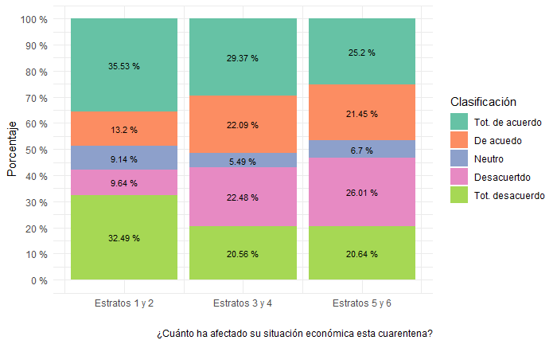

```r
ggsave("PlotAfectacionEconom.jpeg")
```

## Acuerdo o Desacuerdo con las medidas

Pregunta: Indique el grado de acuerdo o desacuerdo con las medidas que las autoridades han tomado para enfrentar la pandemia

```r
Data_Medidas <- Data %>% filter(Estrato >0) %>% select(respondent, Ingresos, Medidas)
Data_Medidas <- Data_Medidas[complete.cases(Data_Medidas),]

MedidasSummary <- Data_Medidas %>% group_by(Ingresos, Medidas) %>%
  summarise(Total = n()) %>% ungroup()


MedidasSummary %<>% pivot_wider(id_cols = Ingresos, names_from = Medidas, values_from = Total)
names(MedidasSummary) <- c("Ingreso", "TotalDes", "Des", "Medio", "Deacuerdo", "TotalmDeacuerdo")

MedidasSummary2 <- MedidasSummary
MedidasSummary2$Total <- apply(MedidasSummary2[,-1],1,sum)

MedidasSummary2[,c(2:6)] <- MedidasSummary2[,c(2:6)]/MedidasSummary2$Total
MedidasSummary2[,c(2:6)] <- round(MedidasSummary2[,c(2:6)]*100,2)

MedidasSummary2 %<>% select(-Total)
```

```r
MedidasSummary2
```

| Ingreso | TotalDes | Des | Medio | Deacuerdo | TotalmDeacuerdo |
| --- | --- | --- | --- | --- | --- |
| 1 | 5.64 | 11.79 | 5.64 | 41.03 | 35.90 |
| 2 | 1.49 | 10.66 | 3.47 | 40.77 | 43.62 |
| 3 | 2.60 | 5.47 | 2.86 | 36.72 | 52.34 |

```r
NA
```

```r
Test <- MedidasSummary2 %>% pivot_longer(names_to = "Category", cols = -Ingreso)

ggplot(Test) + geom_bar(aes(fill = Category, x = Ingreso, y = value),
                        position="stack", stat="identity") +
  xlab("") + ylab("Porcentaje") +
  scale_x_continuous(breaks = c(1,2,3),
                     labels = c("Estratos 1 y 2", "Estratos 3 y 4", "Estratos 5 y 6")) +
  scale_y_continuous(breaks = seq(0,100,10),
                     labels = paste(seq(0,100,10),"%")) +
    geom_text(aes(fill = Category, x = Ingreso, y = value, label = paste(value, "%", sep = " ")),
            position = position_stack(vjust = .5), size = 3) +
  scale_fill_manual(name = "Clasificación",
                    values = c("#66c2a5", "#fc8d62",
                                "#8da0cb",
                               "#e78ac3", "#a6d854"),
                      labels = c("Tot. de acuerdo", "De acuedo",
                                 "Neutro",
                                 "Desacuertdo", "Tot. desacuerdo")) +
  labs(caption = "medidas que las autoridades han tomado para enfrentar la pandemia") +
  theme_minimal()
```

```
Ignoring unknown aesthetics: fill
```

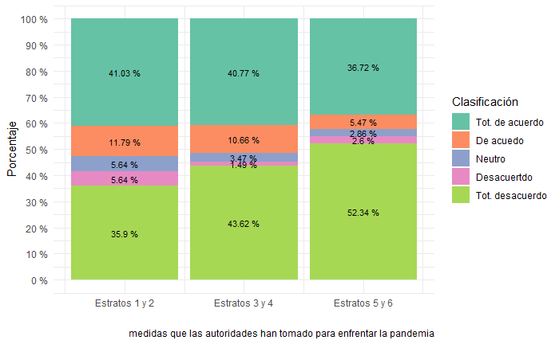

```r
ggsave("PlotMedidas.jpeg")
```

## Aprender Nuevas Tecnologías

Pregunta: ¿La cuarentena lo ha forzado a aprender nuevas tecnologías?

```r
NT_Tiempo <- Data %>% filter(Estrato >0) %>% select(respondent, Ingresos, AprenderNT)
NT_Tiempo <- NT_Tiempo[complete.cases(NT_Tiempo),]

NTSummary <- NT_Tiempo %>% group_by(Ingresos, AprenderNT) %>%
  summarise(Total = n()) %>% ungroup()


NTSummary %<>% pivot_wider(id_cols = Ingresos, names_from = AprenderNT, values_from = Total)
names(NTSummary) <- c("Ingreso", "TotalDes", "Des", "Medio", "Deacuerdo", "TotalmDeacuerdo")

NTSummary2 <- NTSummary
NTSummary2$Total <- apply(NTSummary2[,-1],1,sum)

NTSummary2[,c(2:6)] <- NTSummary2[,c(2:6)]/NTSummary2$Total
NTSummary2[,c(2:6)] <- round(NTSummary2[,c(2:6)]*100,2)

NTSummary2 %<>% select(-Total)
```

```r
NTSummary2
```

| Ingreso | TotalDes | Des | Medio | Deacuerdo | TotalmDeacuerdo |
| --- | --- | --- | --- | --- | --- |
| 1 | 12.90 | 5.38 | 1.61 | 41.40 | 38.71 |
| 2 | 12.36 | 10.81 | 3.47 | 34.75 | 38.61 |
| 3 | 13.37 | 10.70 | 3.21 | 35.83 | 36.90 |

```r
NA
```

```r
Test <- NTSummary2 %>% pivot_longer(names_to = "Category", cols = -Ingreso)

ggplot(Test) + geom_bar(aes(fill = Category, x = Ingreso, y = value),
                        position="stack", stat="identity") +
  xlab("") + ylab("Porcentaje") +
  scale_x_continuous(breaks = c(1,2,3),
                     labels = c("Estratos 1 y 2", "Estratos 3 y 4", "Estratos 5 y 6")) +
  geom_text(aes(fill = Category, x = Ingreso, y = value, label = paste(value, "%", sep = " ")),
            position = position_stack(vjust = .5)) +
  scale_y_continuous(breaks = seq(0,100,10),
                     labels = paste(seq(0,100,10),"%")) +
  scale_fill_manual(name = "Clasificación",
                    values = c("#66c2a5", "#fc8d62",
                                "#8da0cb",
                               "#e78ac3", "#a6d854"),
                      labels = c("Tot. de acuerdo", "De acuedo",
                                 "Neutro",
                                 "Desacuertdo", "Tot. desacuerdo")) +
  labs(caption = "¿La cuarentena lo ha forzado a aprender nuevas tecnologías?") +
  theme_minimal()
```

```
Ignoring unknown aesthetics: fill
```

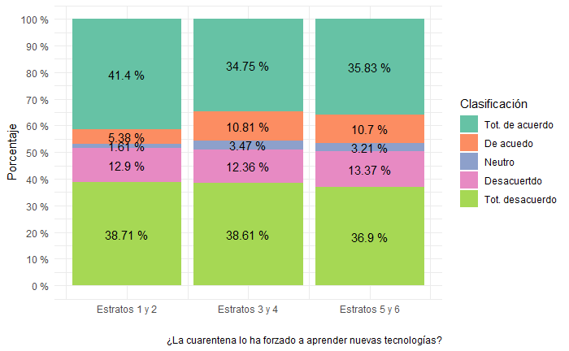

```r
ggsave("PlotNuevasTecnologias.jpeg")
```

## Tiempo Actividad Principal

¿Respecto a la etapa pre-pandemia, el tiempo que invierte semanalmente para realizar su actividad principal cambió ?

```r
ActividadPrincipal <- Data %>% filter(Estrato >0) %>% select(respondent, Ingresos, TiempoActPrinc)
ActividadPrincipal <- ActividadPrincipal[complete.cases(ActividadPrincipal),]

ActividadPrincipalSummary <- ActividadPrincipal %>% group_by(Ingresos, TiempoActPrinc) %>%
  summarise(Total = n()) %>% ungroup()


ActividadPrincipalSummary %<>% pivot_wider(id_cols = Ingresos, names_from = TiempoActPrinc, values_from = Total)
names(ActividadPrincipalSummary) <- c("Ingreso", "NoRealizoActividad",
                                      "Igual", "Aumento", "Disminuyo")

ActividadPrincipalSummary2 <- ActividadPrincipalSummary %>% select(-NoRealizoActividad)
ActividadPrincipalSummary2$Total <- apply(ActividadPrincipalSummary2[,-1],1,sum)

ActividadPrincipalSummary2[,c(2:5)] <- ActividadPrincipalSummary2[,c(2:5)]/ActividadPrincipalSummary2$Total
ActividadPrincipalSummary2[,c(2:5)] <- round(ActividadPrincipalSummary2[,c(2:5)]*100,2)

ActividadPrincipalSummary2 %<>% select(-Total)
```

```r
ActividadPrincipalSummary2
```

[output not shown]

```r
NA
```

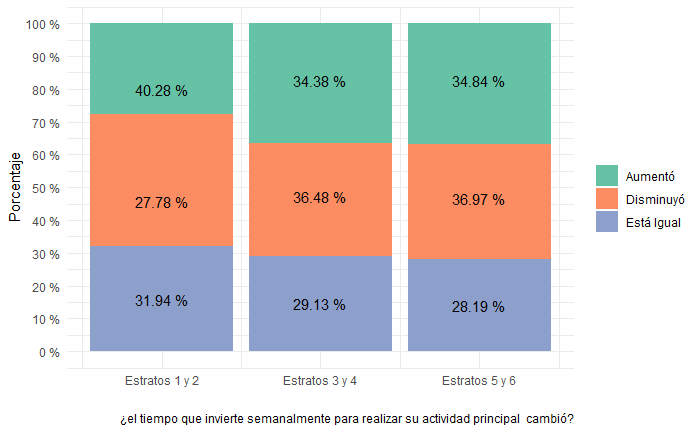

```r
Test <- ActividadPrincipalSummary2 %>% pivot_longer(names_to = "Category", cols = -Ingreso)

ggplot(Test) + geom_bar(aes(fill = Category, x = Ingreso, y = value),
                        position="stack", stat="identity") +
  xlab("") + ylab("Porcentaje") +
  scale_x_continuous(breaks = c(1,2,3),
                     labels = c("Estratos 1 y 2", "Estratos 3 y 4", "Estratos 5 y 6")) +

  geom_text(aes(x = Ingreso, y = value, label = paste(value, "%", sep = " ")),
            position = position_stack(vjust = .5)) +
  scale_y_continuous(breaks = seq(0,100,10),
                     labels = paste(seq(0,100,10),"%")) +
  scale_fill_manual(name = "",
                    values = c("#66c2a5", "#fc8d62",
                                "#8da0cb"),
                      labels = c("Aumentó", "Disminuyó",
                                 "Está Igual")) +
  labs(caption = "¿el tiempo que invierte semanalmente para realizar su actividad principal  cambió?") +
  theme_minimal()

ggsave("PlotCambioTiempoActPrincipal.jpeg")
```

## Modo Actividad Principal Prepandemia

```r
ModoActividadPrincipalPre <- Data %>%
  filter(Estrato >0) %>% select(respondent, Ingresos, ModoPrevio)
ModoActividadPrincipalPre <- ModoActividadPrincipalPre[complete.cases(ModoActividadPrincipalPre),]

# Remove <- ModoActividadPrincipalPre %>% group_by(ModoPrevio) %>%
#   summarise(Total = n()) %>% arrange(desc(Total)) %>% slice(-1)
#
# ModoActividadPrincipalPre %<>% filter(ModoActPrinc %in% Remove$ModoActPrinc[1:6])

ModoActividadPrincipalSummary <- ModoActividadPrincipalPre %>% group_by(Ingresos, ModoPrevio) %>%
  summarise(Total = n()) %>% ungroup()

ModoActividadPrincipalSummary %<>% pivot_wider(id_cols = Ingresos,
                                               names_from = ModoPrevio, values_from = Total)  %>%
  replace(is.na(.), 0)


names(ModoActividadPrincipalSummary)[c(9,10)] <- c("App","Transporte Masivo")

ModoActividadPrincipalSummary2 <- ModoActividadPrincipalSummary
ModoActividadPrincipalSummary2$Total <- apply(ModoActividadPrincipalSummary2[,-1],1,sum)

ModoActividadPrincipalSummary2[,c(2:14)] <- ModoActividadPrincipalSummary2[,c(2:14)]/ModoActividadPrincipalSummary2$Total
ModoActividadPrincipalSummary2[,c(2:14)] <- round(ModoActividadPrincipalSummary2[,c(2:14)]*100,2)

ModoActividadPrincipalSummary2 %<>% select(-Total)
```

```r
ModoActividadPrincipalSummary2
```

| Ingresos | Automóvil | Bicicleta propia | Bus convencional | Caminando | Motocicleta | Mototaxi/Motocarro | Otro | App | Transporte Masivo | Bicitaxi | Patineta eléctrica | Taxi tradicional | Bicicleta pública |
| --- | --- | --- | --- | --- | --- | --- | --- | --- | --- | --- | --- | --- | --- |
| 1 | 9.80 | 5.88 | 18.43 | 5.10 | 9.02 | 2.75 | 0.78 | 0.39 | 47.84 | 0.00 | 0.00 | 0.00 | 0.00 |
| 2 | 29.40 | 6.65 | 14.59 | 9.33 | 4.08 | 0.23 | 1.75 | 3.03 | 27.07 | 0.12 | 0.47 | 3.27 | 0.00 |
| 3 | 52.66 | 6.04 | 4.83 | 10.87 | 0.48 | 0.24 | 2.42 | 4.83 | 13.04 | 0.00 | 0.72 | 3.62 | 0.24 |

```r
NA
```

[figure not shown]

```r
Test <- ModoActividadPrincipalSummary2 %>% pivot_longer(names_to = "Category", cols = -Ingresos)

ggplot(Test) + geom_bar(aes(fill = Category, x = Ingresos, y = value),
                        position="stack", stat="identity") +
  ylab("Porcentaje") +
  scale_x_continuous(breaks = c(1,2,3),
                     labels = c("Estratos 1 y 2", "Estratos 3 y 4",
                                 "Estratos 5 y 6")) +
  scale_y_continuous(breaks = seq(0,100,10),
                     labels = paste(seq(0,100,10),"%")) +
  # scale_fill_manual(name = "",
  #                   values = c("#66c2a5", "#fc8d62",
  #                               "#8da0cb"),
  #                     labels = c("Aumentó", "Disminuyó",
  #                                "Está Igual")) +
  labs(caption = "Medio de transporte usado previamente (pre-pandemia)") +
  theme_minimal()
```

```r
#ggsave("PlotCambioTiempoActPrincipal.jpeg")
```

## Modo Actividad Principal Cuarentena

Si su respuesta fue que su medio de transporte cambió, ¿Qué medio de transporte usa para ir a realizar su actividad principal en la actualidad?

```r
ModoActividadPrincipal <- Data %>%
  filter(Estrato >0) %>% select(respondent, Ingresos, ModoActPrinc)
ModoActividadPrincipal <- ModoActividadPrincipal[complete.cases(ModoActividadPrincipal),]

Remove <- ModoActividadPrincipal %>% group_by(ModoActPrinc) %>%
  summarise(Total = n()) %>% arrange(desc(Total)) %>% slice(-1)

ModoActividadPrincipal %<>% filter(ModoActPrinc %in% Remove$ModoActPrinc[1:6])

ModoActividadPrincipalSummary <- ModoActividadPrincipal %>% group_by(Ingresos, ModoActPrinc) %>%
  summarise(Total = n()) %>% ungroup()

ModoActividadPrincipalSummary %<>% pivot_wider(id_cols = Ingresos,
                                               names_from = ModoActPrinc, values_from = Total)  %>%
  replace(is.na(.), 0)


names(ModoActividadPrincipalSummary)[7] <- c("Transporte Masivo")

ModoActividadPrincipalSummary2 <- ModoActividadPrincipalSummary
ModoActividadPrincipalSummary2$Total <- apply(ModoActividadPrincipalSummary2[,-1],1,sum)

ModoActividadPrincipalSummary2[,c(2:7)] <- ModoActividadPrincipalSummary2[,c(2:7)]/ModoActividadPrincipalSummary2$Total
ModoActividadPrincipalSummary2[,c(2:7)] <- round(ModoActividadPrincipalSummary2[,c(2:7)]*100,2)

ModoActividadPrincipalSummary2 %<>% select(-Total)
```

```r
ModoActividadPrincipalSummary2
```

| Ingresos | Automóvil | Bicicleta propia | Bus convencional | Caminando | Taxi tradicional | Transporte Masivo |
| --- | --- | --- | --- | --- | --- | --- |
| 1 | 5.56 | 4.17 | 5.56 | 12.50 | 2.78 | 69.44 |
| 2 | 30.49 | 8.54 | 8.54 | 18.29 | 8.54 | 25.61 |
| 3 | 70.59 | 0.00 | 11.76 | 11.76 | 5.88 | 0.00 |

```r
NA
```

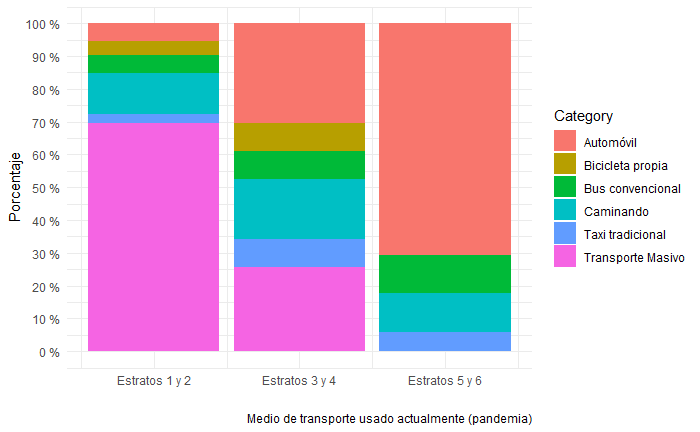

```r
Test <- ModoActividadPrincipalSummary2 %>% pivot_longer(names_to = "Category", cols = -Ingresos)

ggplot(Test) + geom_bar(aes(fill = Category, x = Ingresos, y = value),
                        position="stack", stat="identity") +
  xlab("") + ylab("Porcentaje") +
  scale_x_continuous(breaks = c(1,2,3),
                     labels = c("Estratos 1 y 2", "Estratos 3 y 4",
                                 "Estratos 5 y 6")) +
  scale_y_continuous(breaks = seq(0,100,10),
                     labels = paste(seq(0,100,10),"%")) +
  # scale_fill_manual(name = "",
  #                   values = c("#66c2a5", "#fc8d62",
  #                               "#8da0cb"),
  #                     labels = c("Aumentó", "Disminuyó",
  #                                "Está Igual")) +
  labs(caption = "Medio de transporte usado actualmente (pandemia)") +
  theme_minimal()
```

```r
#ggsave("PlotCambioTiempoActPrincipal.jpeg")
```

#Sankey

```r
SankeyData <- Data %>% select(respondent, Ingresos, ModoPrevio, ModoActPrinc) %>%
  mutate(Ingresos = as.factor(Ingresos))
SankeyData <- SankeyData[complete.cases(SankeyData),]

#levels(as.factor(Data$ModoPrevio))
#levels(as.factor(Data$ModoActPrinc))

SankeyData %<>%
  mutate(ModoPrevio =
           recode(ModoPrevio,
"Automóvil" = "Vehículo Privado",
"Bicicleta propia" = "Bicicleta",
"Bicicleta pública" = "Bicicleta",
"Bicitaxi" = "Bicicleta",
"Bus convencional" = "Transporte Público",
"Caminando"   = "Caminar",
"Motocicleta"   = "Vehículo Privado",
"Mototaxi/Motocarro" = "Taxi y plataformas",
"Otro" = "Otro",
"Patineta eléctrica" = "Otro",
"Servicios de transporte por aplicación" = "Taxi y plataformas",
"Taxi tradicional" = "Taxi y plataformas",
"Transporte masivo (ejemplo: Transmilenio, Transmetro, Metro, Metroplus, MIO)" = "Transporte Público"))


SankeyData %<>%
  mutate(ModoActPrinc =
           recode(ModoActPrinc,
"Automóvil" = "Vehículo Privado",
"Bicicleta propia" = "Bicicleta",
"Bicicleta pública" = "Bicicleta",
#"Bicitaxi" = "Bicicleta",
"Bus convencional" = "Transporte Público",
"Caminando"   = "Caminar",
"Motocicleta"   = "Vehículo Privado",
"Mototaxi/Motocarro" = "Taxi y plataformas",
"Ninguno (actualmente realiza su actividad principal desde casa)" = "Ninguno",
"Otro" = "Otro",
"Patineta eléctrica" = "Otro",
"Servicios de transporte por aplicación" = "Taxi y plataformas",
"Taxi tradicional" = "Taxi y plataformas",
"Transporte masivo (ejemplo: Transmilenio, Transmetro, Metro, Metroplus, MIO)" = "Transporte Público"))
```

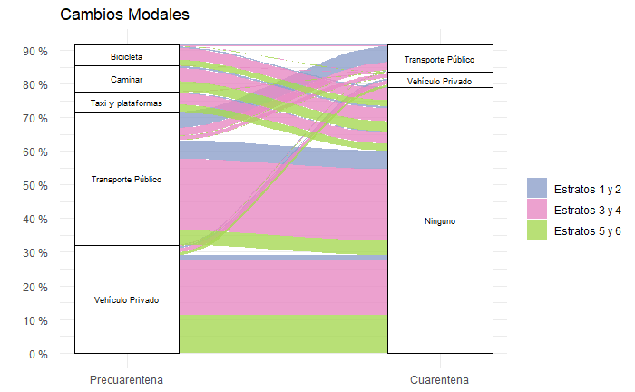

```r
SankeyDataGroup <- SankeyData %>% group_by(ModoPrevio, ModoActPrinc, Ingresos) %>%
  summarise(Total = n()) %>% ungroup() %>%
  mutate(Flow = ModoPrevio)

TotalFlujo <- sum(SankeyDataGroup$Total)

SankeyDataGroup %<>% mutate(Prop = Total/TotalFlujo) %>%
  mutate(Prop = round(Prop*100, 2))

SankeyDataGroup %<>% filter(ModoPrevio != "Otro") %>%
  filter(ModoActPrinc %in% c("Vehículo Privado", "Transporte Público", "Ninguno"))

ggplot(SankeyDataGroup,
       aes(axis1 = ModoPrevio,
           axis2 = ModoActPrinc,
           y = Prop)) +
  geom_alluvium(aes(fill = Ingresos), alpha = 0.8) +
  geom_stratum(width = 1/3) +
  geom_text(stat = "stratum",
            label.strata = TRUE,
            size = 2.5) +
  scale_x_discrete(limits = c("Precuarentena", "Cuarentena"),
                   expand = c(0.02, 0.02)) +
  scale_y_continuous(breaks = seq(0,100,10),
                     labels = paste(seq(0,100,10), "%", " ")) +
  scale_fill_manual(name = "",
                    values = c("#8da0cb",
                               "#e78ac3", "#a6d854"),
                      labels = c("Estratos 1 y 2", "Estratos 3 y 4",
                                 "Estratos 5 y 6")) +

  labs(title = "Cambios Modales") + ylab("") +
  #coord_flip() +
  theme_minimal() #+ theme(legend.position = "none")

ggsave("Sankey.jpeg")
```

# Maps

```r
Data_Economico_Geo <- Locations %>% left_join(Data_Economico) %>%
  filter(!is.na(Ingresos))
```

```r
Data_Medidas_Geo <- Locations %>% left_join(Data_Medidas) %>%
  filter(!is.na(Ingresos))
```

```r
Zones <- st_read("ZATs/ZATs_2012_MAG.shp")
ZonesBackground <- st_read("OD 2011 Survey/ZonesBackground.shp")
ZonesGeneration2 <- st_read("AuxiliaryGeographicFiles/ZonesGeneration2.shp")
Bogota <- st_read("AuxiliaryGeographicFiles/ZonesBogota.shp")
Transmilenio <- st_read("AuxiliaryGeographicFiles/Transmilenio.shp")
```

```r
BB <- st_bbox(ZonesGeneration2)
BB[3] <- -74
BB[4] <- 4.85
BB[2] <- 4.47
```

```r
Breaks <- c(0,1.1, 2.1, 3.1, 4.1, 5.1)
Labels <- c("Tot. Desacuerdo", "Desacuerdo", "Neutro", "De acuerto", "Tot. De acuerdo"
)
```

```
The argument size of tm_scale_bar is deprecated. It has been renamed to text.sizebounding box has potentially an invalid value range for longlat data
```

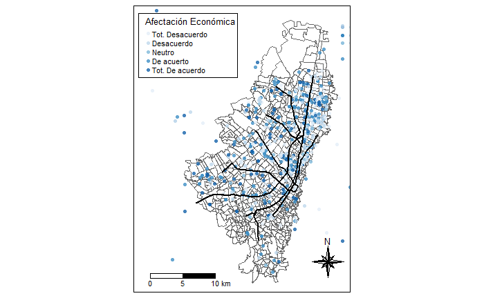

```r
tm_shape(Bogota,bbox = BB) +
  tm_borders() +
# tm_shape(MyZones) +
#   tm_polygons(col = "Diff_Employment",
#               breaks = BreaksUberJobs, palette="YlGn",
#               title = "Differences in accessible jobs",
#               labels= BreaksLabelsUberJobs
#               ) +
  tm_shape(Data_Economico_Geo) +
    tm_dots(size = 0.13, col = "AfectEconomica", alpha = 0.8,
            palette = "Blues",
            title = "Afectación Económica",
            breaks = Breaks, labels = Labels) +
  tm_shape(Transmilenio) +
    tm_lines(lwd = 2) +
 tm_compass(type = "8star", position = c(0.8, 0.05),size=3) +
 tm_scale_bar(breaks = c(0, 5, 10), size = 0.7, position = c(0.06,0))+
 tm_layout(legend.position = c(0.02,0.75),
           legend.title.size = 1,
           legend.frame = T,legend.width = 1.7)
```

```
The argument size of tm_scale_bar is deprecated. It has been renamed to text.sizebounding box has potentially an invalid value range for longlat data
```

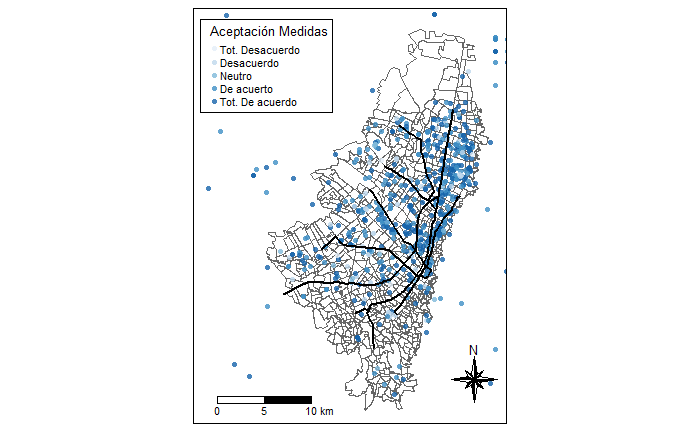

```r
tm_shape(Bogota,bbox = BB) +
  tm_borders() +
# tm_shape(MyZones) +
#   tm_polygons(col = "Diff_Employment",
#               breaks = BreaksUberJobs, palette="YlGn",
#               title = "Differences in accessible jobs",
#               labels= BreaksLabelsUberJobs
#               ) +
  tm_shape(Data_Medidas_Geo) +
    tm_dots(size = 0.13, col = "Medidas", alpha = 0.8,
            palette = "Blues",
            title = "Aceptación Medidas",
            breaks = Breaks, labels = Labels) +
  tm_shape(Transmilenio) +
    tm_lines(lwd = 2) +
 tm_compass(type = "8star", position = c(0.8, 0.05),size=3) +
 tm_scale_bar(breaks = c(0, 5, 10), size = 0.7, position = c(0.06,0))+
 tm_layout(legend.position = c(0.02,0.75),
           legend.title.size = 1,
           legend.frame = T,legend.width = 1.7)
```

# TO DO

[12:31 PM, 4/21/2020] Daniel Oviedo: Los análisis de datos hazlo para los 3 grupos de ingreso, por género y por sector de trabajoaver que sale. Clave: las percepciones, quien se esta quedando en casa para que actividades y como han cambiado modos de transporte [12:32 PM, 4/21/2020] Daniel Oviedo: Lo de dedicaciones de tiempo basta con las preguntas de si aumento o disminuyó